# **Estadística Empresarial I** Tema 2: Medidas de Posición

Fernando A. López** Catedrático de Universidad Facultad de CC de la Empresa Universidad Politécnica de Cartagena

2023-09-11

# 1 Características de una distribución de frecuencias

Una distribución de frecuencias es la agrupación ordenada de datos en intervalos o categorías mutuamente excluyentes en la que se indica la frecuencia con la que ocurren. Estas distribuciones resaltan patrones y tendencias en conjuntos de datos, permitiendo un análisis más profundo. Las características clave incluyen clases o intervalos que dividen el rango de datos, frecuencias que indican cuántas veces ocurre cada valor en una clase, y la suma total de frecuencias que coincide con el tamaño del conjunto de datos.

El objetivo de realizar este tipo de agrupaciones de valores es resumir en solo unos pocos números la información, tanto sea para interpretar el fenómeno, como para comparar unos fenómenos con otros.

Con el fin de resumir la información, se han creado una serie de indicadores o “medidas” que intentan describir el fenómeno. Estas medidas pueden clasificarse fundamentalmente en tres tipos dependiendo de la característica que se quiera sintetizar:

1. **Medidas de posición:** Intentan resumir globalmente el fenómeno.
2. **Medidas de dispersión:** Miden el grado de variabilidad de los datos respecto a una medida de tendencia central (p.e. media aritmética).
3. **Medidas de forma:** Asimetría y curtosis para evaluar el grado de simetría de la distribución y su apuntamiento (puntiaguda o plana).

Estas medidas deben tener tres características fundamentales gracias a las cuales se consideran operativas:

1. En su elaboración intervienen todos y cada uno de los valores de la variable.
2. Son siempre calculables.
3. Son únicas para cada distribución.

# 2 Medidas de posición centrales

## 2.1 La media aritmética.

La media aritmética es una de las medidas estadísticas más fundamentales y ampliamente utilizadas. Su importancia radica en su capacidad para resumir un conjunto de datos en un solo número representativo. Al sumar todos los valores y dividir por el número de observaciones, proporciona una medida del valor promedio en un conjunto. Esto es esencial en campos como la economía y la empresa, donde es crucial en la toma de decisiones empresariales y planificación financiera. La media aritmética simplifica datos complejos, permitiendo comparaciones y análisis más sencillos, y es una herramienta valiosa en la investigación y la toma de decisiones.

Dada una distribución de frecuencias $(x_i,n_i)$ sin agrupar en intervalos, se define la media aritmética como sigue:

$$\bar{x} ={1 \over N}(x_1n_1+x_2n_2+...+x_nn_n) ={1 \over N} \sum_{i=1}^n{x_in_i}$$

Es decir la media aritmética es la suma de todos los valores de la distribución dividida por el número total de observaciones.

En el caso de que la distribución de frecuencias esté agrupada en intervalos se tomará como valores de la variable $X$ las marcas de clase de cada uno de los intervalos.

La media aritmética puede interpretarse como una media ponderada en el sentido de que a cada valor que toma la variable $x_i$ se le asigna tanta importancia como número de veces se haya repetido en las observaciones $n_i$. Esto no tiene porque ser siempre así, y es posible que en determinados casos se sustituyan las ponderaciones o pesos que se han considerado en este caso (las frecuencias absolutas) por otros que se consideren más importantes en ese momento.

### 2.1.1 Propiedades de la media aritmética

**Propiedad 1.** La suma de las desviaciones de los valores de la variable respecto a su media aritmética es cero.
$$\sum_{i=1}^n{(x_i- \bar x)n_i}=0$$
*Demostración:* En clase

**Propiedad 2.** La suma de las desviaciones al cuadrado de los valores de la variable respecto a una constante $c$ cualquiera, se hace mínima cuando $c = \bar x$ (*Teorema de König*).

$$\min_c \sum_{i=1}^n{(x_i- c)^2n_i}=\sum_{i=1}^n{(x_i- \bar x)^2n_i}$$

*Demostración:* En clase

**Propiedad 3:** (*Cambio de origen*) Si a todos los valores que toma una variable se le suma una cantidad constante $a$, la media aritmética queda también aumentada en esa constante.

$$Y=X+a \Rightarrow \bar y = \bar x + a$$

*Demostración:* En clase

**Propiedad 4:** (*Cambio de escala*). Si todos los valores que toma una variable se multiplican por una misma constante $b$, la media aritmética queda también multiplicada por esa constante.

$$Y = bX \Rightarrow \bar y = b \bar x$$

*Demostración:* En clase

**Propiedad 5.** Si de un conjunto de valores se obtienen dos o más conjuntos disjuntos, la media aritmética de todo el conjunto se relaciona con todas las medias aritméticas de los diferentes subconjuntos disjuntos.

$$\bar x_T ={1 \over N}(N_1 \bar x_1 +N_2 \bar x_2 +...+N_k \bar x_k )$$

*Demostración:* Sin demostración

Cálculo abreviado de la media aritmética.

Con objeto de agilizar el cálculo práctico de la media aritmética cuando la distribución se presenta con numerosos valores o éstos están compuestos por bastantes dígitos, es aconsejable realizar el siguiente cambio de variable:

$$Y = {{ X - a} \over b}$$
De tal forma que

$$\bar y = {{\bar x - a} \over b} \Rightarrow \bar x=a+b \bar y$$

## 2.2 La media geométrica

La media geométrica, que se representa por $G$, se define como la raíz N-ésima del producto de los N valores de la distribución. Es decir:

$$G=\sqrt[N]{x_1^{n_1}x_2^{n_2}...x_n^{n_n}}$$

Para calcular de una forma más simple la media geométrica se pueden tomar logaritmos (neperianos) en la expresión anterior, obteniendo:

$$ln \ G={1 \over N} \sum_{i=1}^n{ln(x_i)n_i}$$

Si se realiza el cambio $y_i=ln(x_i)$ se tiene que $lnG=\bar y$ y por tanto $G=e^{\bar y}$.

En este sentido puede entenderse que la media geométrica de $X$ es la exponencial de la media aritmética de los logaritmos de $X$.

La media geométrica no verifica la segunda de las condiciones que se requerían en una medida de síntesis: *la existencia*. En efecto, es posible encontrar situaciones en las que no sea posible calcular G (radicando negativo con radical par). Otra nota que se debe hacer sobre esta media es su ineficacia para promediar resultados cuando la variable en estudio toma entre sus posibles valores el valor cero. En estos casos la media geométrica siempre valdrá cero distorsionando el promedio.

A pesar de no verificar esta condición la media geométrica es imprescindible a la hora de promediar tasas y porcentajes ya que en estos casos la media aritmética no es el promedio correcto.

> *La media geométrica es especialmente útil cuando se trata de datos que representan tasas de crecimiento, ratios, o magnitudes que se multiplican entre sí, como porcentajes de crecimiento, rendimientos financieros, o tasas de interés compuestas*

### 2.2.1 Ejemplo

Supongamos que un inversionista está interesado en evaluar el rendimiento promedio de su cartera de acciones durante un período de cinco años. Cada año, las acciones tienen un rendimiento diferente, y el inversionista desea calcular una medida que refleje el crecimiento promedio anual de su inversión.

A continuación, se presenta un ejemplo hipotético de rendimientos anuales:

- Año 1: 15%
- Año 2: 10%
- Año 3: -5%
- Año 4: 12%
- Año 5: 8%

Para calcular el rendimiento promedio geométrico de esta cartera de acciones durante los cinco años, se utiliza la siguiente fórmula:

$$\text{G} = \sqrt[5]{(1 + 0.15) \cdot (1 + 0.10) \cdot (1 - 0.05) \cdot (1 + 0.12) \cdot (1 + 0.08)} - 1$$

Esta aplicación de la media geométrica es relevante para los inversionistas y gestores de carteras que desean evaluar cómo sus inversiones crecen a lo largo del tiempo y obtener una estimación más precisa del rendimiento promedio ajustado por la variabilidad de los rendimientos anuales.

## 2.3 La media armónica

Dada una distribución de frecuencias $(x_i,n_i)$, la media armónica se define como:

$$H = {1 \over {1 \over N} \sum\limits_{i=1}^n {1 \over x_i}n_i}$$

Si se realiza el cambio $y_i={1 \over x_i}$ es fácil comprobar que $H=\bar y^{-1}$

Al igual que en el caso anterior, la media armónica $H$ no verifica la condición de existencia ya que en aquellos casos en los que la variable toma el valor cero (o el valor del denominador es cero) no es posible calcularla. No obstante, como en el caso anterior, esta media es imprescindible a la hora de promediar rendimientos.

> *La media armónica tiende a dar más peso a los valores más pequeños en el conjunto de datos, y es especialmente útil en situaciones en las que se desea calcular un promedio que refleje proporciones o tasas inversas, como velocidades, tasas de rendimiento, o tasas de cambio*

De las tres medias presentadas la más importante, debido a su mayor utilización, es la media aritmética, siendo las otras dos complementarias ya que su uso está restringido a unos casos muy especiales.

### 2.3.1 Ejemplo

Un agricultor tiene varias parcelas de maíz y desea calcular el rendimiento promedio de sus parcelas para determinar cuál es la producción media por hectárea. A lo largo de la temporada de cultivo, el agricultor registra el rendimiento de cada parcela en toneladas por hectárea (t/ha).

Los rendimientos de las parcelas son los siguientes:

- Parcela 1: 5 t/ha; con una produccion total de 20t
- Parcela 2: 6 t/ha; con una produccion total de 18t
- Parcela 3: 4 t/ha; con una produccion total de 12t
- Parcela 4: 7 t/ha; con una produccion total de 14t

Para calcular el rendimiento promedio de todas las parcelas de maíz, se utiliza la media armónica:

$$Rendimiento_T= {toneladas_T \over hectareas_T} = \\
= {{20+18+12+14} \over {20/5 + 18/6 +12/4 + 14/7}} = {64 \over 12}=5,33$$
## Relación entre los tres promedios

Para la misma distribución de frecuencias siempre se verifica la siguiente relación:

$$H \leq G \leq \bar x$$

*Demostración:* Sin demostración

## 2.4 La Mediana

No siempre la media aritmética es la medida de tendencia central que mejor resume los datos obtenidos mediante la observación de un determinado fenómeno. Hay casos en los que el valor de la media aritmética se encuentra distorsionado por la presencia de observaciones atípicas de la distribución. Para clarificar lo dicho anteriormente se puede considerar el siguiente ejemplo:

> *No siempre la media aritmética es la medida de tendencia central que mejor resume los datos*

Se estudian los ingresos de las familias que viven en un determinado edificio y se obtienen los siguientes datos:

$$75 ;\ 120 ;\ 90 ;\ 65 ;\ 105 ;\ 110 ;\ 2100 \ (valor \ atípico¿?) ;\ 95 ;\ 140 ;\ 90$$

Si se calcula la media aritmética de este conjunto de observaciones da como resultado $\bar x= 299$, situación ésta muy alejada de la realidad ya que no refleja al conjunto de onservaciones. Por el contrario, si se consideran las observaciones obtenidas eliminando la observación atípica tendremos $\bar x=98,8$ media que sintetiza mejor la realidad del fenómeno que se estudia. Esta solución no puede ser válida ya que una de las premisas que se ha planteado al principio del tema es la de no eliminar información de forma subjetiva.

La mediana vendrá a resolver este tipo de situaciones en las que se encuentran observaciones atípicas tanto por exceso como por defecto. Esta nueva medida de tendencia central se define como:

> *La mediana es aquel valor de la variable, supuesto que éstos se encuentran ordenados de menor a mayor, que deja a la izquierda el mismo número de observaciones que a la derecha. Esto es, la mediana es aquel valor de la variable que divide la distribución en dos partes iguales dejando a cada lado el 50 % de las frecuencias. La mediana se designa por Me.*

Se puede dar una definición más precisa distinguiendo los siguientes casos:

1. Distribuciones no agrupadas en intervalos.
- N es impar. Entonces: $Me$ = El valor central de la distribución.
- N es par. Entonces: $Me$ = La media aritmética de los valores centrales.
2. Distribuciones agrupadas en intervalos.

$$Me = L_{i-1} + \frac{ N/2 - N_{i-1}} {{n_i}} \cdot (L_{i}-L_{i-1})$$

> *La mediana tiene además la propiedad de que hace mínima la suma de todas las desviaciones absolutas.*

Esto formalmente se expresa:

$$\min_k {\sum_{i=1}^{n}|x_i - k|} = \sum_{i=1}^{n} |x_i - Me|$$
*Demostración:* Sin demostración

## 2.5 La Moda

La moda de una distribución de frecuencias se define como el valor de la variable que más veces se repite, esto es, aquel que tenga una frecuencia absoluta mayor.

> *Si la distribución está agrupada en intervalos, no se empleará aquí el término de moda sino el de intervalo modal, que se corresponderá con aquel que posea la mayor frecuencia absoluta*

Es posible encontrar distribuciones de frecuencias con más de una moda (bimodales, trimodales, etc,…) incumpliéndose así aquel principio que exigía unicidad para cualquier medida de síntesis, no obstante, esta medida es extremadamente útil como medida de posición de variables cualitativas en las que las anteriores medidas no son practicables. Concretamente, esta medida de tendencia central es más representativa en distribuciones dadas en escala nominal (datos susceptibles de ser ordenados) como puede ser el sexo, el estado civil, etc….

# 3 Notas de las PAU

El [Ministerio de Educación y FP](https://www.universidades.gob.es/estadistica-de-las-pruebas-de-acceso-a-la-universidad-pau/) publica un gran conjunto de datos sobre los resultados de las PAU. La siguiente tabla muestra la distribución de las notas en **Matemáticas Aplicadas a las CC Sociales II** para diversos años (valores en porcentaje)

|  | 2022 | 2021 | 2020 | 2019 | 2018 | 2017 | 2016 | 2015 |
| --- | --- | --- | --- | --- | --- | --- | --- | --- |
| De 0 a 5 | 23,70 | 22,62 | 29,92 | 29,05 | 27,11 | 29,04 | 24,05 | 20,3 |
| De 5 a 6 | 13,55 | 12,92 | 14,07 | 16,48 | 14,94 | 16,20 | 15,28 | 12,71 |
| De 6 a 7 | 13,95 | 13,68 | 13,86 | 15,29 | 14,81 | 15,43 | 14,74 | 13,47 |
| De 7 a 8 | 15,03 | 14,96 | 14,14 | 15,04 | 14,97 | 14,84 | 14,59 | 14,57 |
| De 8 a 9 | 15,18 | 15,43 | 13,47 | 12,90 | 13,82 | 12,65 | 14,58 | 15,32 |
| De 9 a 10 | 18,59 | 20,39 | 14,54 | 11,25 | 14,34 | 11,85 | 16,75 | 23,63 |

[interactive chart not shown]

La media aritmética de la nota en 2022 fue de 6,42 mientras que en 2015 fue de 6,72.

Calcular la mediana y el intervalo modal

# 4 Medidas de posición no centrales.

Las medidas de posición no centrales permiten describir la distribución de un conjunto de datos de manera más completa que las medidas de tendencia central (como la media o la mediana) solas. Mientras que las medidas de tendencia central se centran en un valor específico, los **cuantiles** muestran cómo se distribuyen los datos en diferentes partes del conjunto.

Se pueden definir además una serie de valores notables que no reflejan la tendencia de las observaciones. Estos valores, llamados de forma genérica cuantiles (o cuantilas) generalizan la idea de mediana separando la distribución en partes iguales. En este apartado se destacan, y se establece la forma de cálculo de los más importantes: cuartiles, deciles y percentiles.

## 4.1 Cuartiles.

Los **cuartiles** son valores estadísticos que dividen un conjunto de datos ordenados en cuatro partes iguales. Estos valores son útiles para comprender la distribución y dispersión de los datos en un conjunto. Los cuartiles dividen los datos en tres puntos que representan los límites entre los cuatro cuartos del conjunto. Esto es, el primer cuartil es aquel valor de la variable tal que el 25% de las observaciones son inferiores a él y el 75% superiores. El segundo cuartil tiene una definición totalmente semejante y por tanto coincide con la mediana. Por último el tercer cuartil es aquel valor de la variable tal que el 75% de las observaciones son inferiores a él y el 25% superiores.

La forma de determinar estos valores es, al igual que ocurría con la mediana, diferente según se trate de distribuciones sin agrupar en intervalos o agrupadas. En el caso de distribuciones sin agrupar por intervalos, los cuartiles se obtendrán mediante un simple cálculo sobre las frecuencias absolutas.

$$C_k = L_{i-1} + \frac{{\frac{kN}{4} - N_{i-1}}}{{n_i}} \cdot (L_{i}-L_{i-1});\ k=1,2,3$$

siendo $(L_{i},L_{i-1}]$ el intervalo intercuartílico.

## 4.2 Deciles

La filosofía de estas medidas de posición no centrales es totalmente semejante a la de los cuartiles, con la salvedad de que ahora los deciles dividen a la distribución en 10 partes iguales. Así por ejemplo, el tercer decil es aquel valor de la variable tal que el 30% de las observaciones son inferiores a él y el 70% superiores, el sexto decil es aquel valor de la variable tal que el 60% de las observaciones son inferiores a él y el 40% superiores.

La expresión correspondiente que nos da el valor de los deciles en distribuciones agrupadas por intervalos es la siguiente:

$$D_k = L_{i-1} + \frac{{\frac{kN}{10} - N_{i-1}}}{{n_i}} \cdot (L_{i}-L_{i-1});\ k=1,2,...,9$$

## 4.3 Percentiles.

$$P_k = L_{i-1} + \frac{{\frac{kN}{100} - N_{i-1}}}{{n_i}} \cdot (L_{i}-L_{i-1});\ k=1,2,...,99$$

## 4.4 Ejemplo de uso de los percentiles

El porcentaje de votantes a determinado partido en función de la renta puede mostrarse utilizando la información que suministran los percentiles de renta.

https://www.eldiario.es/politica/demografia-votos-elecciones-generales-23j_1_10377815.html

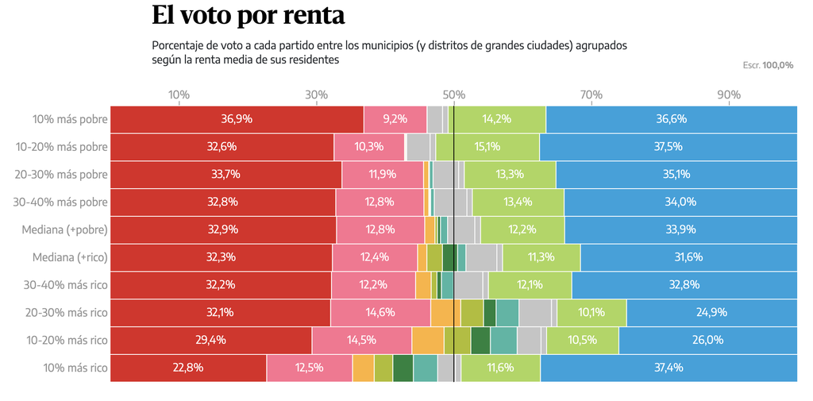

Publicado en elDiario.es

En el caso de los resultados de la Región de Murcia

[interactive chart not shown]

# 5 Cuartiles PAU

Los cuartiles de la distribución de las notas de la PAU de la seccion Notas de las PAU puede calculase a pesar de no tener el total de observaciones.

$$C_k=L_{i-1}+((k/4)(N/n_i) - N_{i-1}/n_i)(L_{i}-L_{i-1})= \\
=L_{i-1}+ ({k \over 4f_i} - {F_{i-1} \over f_i})(L_{i}-L_{i-1})$$
El siguiente gráfico muestra la nota media junto con el rango de variación del 50% de las observaciones centrales (rango intercuartílico). Nótese que en los años 2022 y 2021 se cambio el tipo de examen permitiendo elegir 4 ejercicios sobre 10 frente a la anterior versión en la que había dos modelos opcionales.

[interactive chart not shown]